# ESTADISTICA PARA EL ANALISIS POLITICO II

- Profesor: [Dr. José Manuel Magallanes, Ph.D.](http://www.pucp.edu.pe/profesor/jose-manuel-magallanes/)
  - Profesor del Departamento de Ciencias Sociales, Sección de Ciencia Política y Gobierno.
  - [Oficina 105](https://goo.gl/maps/xuGeG6o9di1i1y5m6) - Edificio CISEPA / ECONOMIA / CCSS
  - Telefono: (51) 1 - 6262000 anexo 4302
  - Correo Electrónico: jmagallanes@pucp.edu.pe

## Introducción a la Regresión Lineal Multivariada

En esta sesión deseo que entiendas por qué es necesario ir más allá de la correlación (*Pearson*, *Spearman*, etc.) o las diferencias de valores medios (*t test*, *kruska wallis*, etc.). Esta necesidad de ir más allá tiene una técnica de apoyo conocida como la regresión.

La sesión va en tres partes:

- De Correlación a Regresión
- Regresión Lineal
- Diagnósticos de la Regresión

## I. De Correlación a regresión

Trabajemos con los datos del archivo en SPSS **hsb.sav**:

```r
library(rio)
linkToData='https://github.com/PsicologiaPUCP/ArchivosDeDatos/raw/master/hsb_ok.sav'
hsb=import(linkToData)
```

Revisando tipo de datos:

```r
str(hsb)
```

```
## 'data.frame':    600 obs. of  15 variables:
##  $ ID    : chr  "    1" "    2" "    3" "    4" ...
##   ..- attr(*, "label")= chr "Student identification number"
##   ..- attr(*, "format.spss")= chr "A5"
##  $ SEX   : num  2 1 2 2 2 1 1 2 1 2 ...
##   ..- attr(*, "label")= chr "Sex"
##   ..- attr(*, "format.spss")= chr "F5.0"
##   ..- attr(*, "labels")= Named num  1 2
##   .. ..- attr(*, "names")= chr  "Male" "Female"
##  $ RACE  : num  2 2 2 2 2 2 2 2 2 2 ...
##   ..- attr(*, "label")= chr "Race or ethnicity"
##   ..- attr(*, "format.spss")= chr "F5.0"
##   ..- attr(*, "labels")= Named num  1 2 3 4
##   .. ..- attr(*, "names")= chr  "Hispanic" "Asian" "Black" "White"
##  $ SES   : num  1 1 1 2 2 2 1 1 2 1 ...
##   ..- attr(*, "label")= chr "Socioeconomic status"
##   ..- attr(*, "format.spss")= chr "F5.0"
##   ..- attr(*, "labels")= Named num  1 2 3
##   .. ..- attr(*, "names")= chr  "Low" "Medium" "High"
##  $ SCTYP : num  1 1 1 1 1 1 1 1 1 1 ...
##   ..- attr(*, "label")= chr "School type"
##   ..- attr(*, "format.spss")= chr "F5.0"
##   ..- attr(*, "labels")= Named num  1 2
##   .. ..- attr(*, "names")= chr  "Public" "Private"
##  $ HSP   : num  3 2 2 3 3 2 1 1 1 1 ...
##   ..- attr(*, "label")= chr "High school program"
##   ..- attr(*, "format.spss")= chr "F5.0"
##   ..- attr(*, "labels")= Named num  1 2 3
##   .. ..- attr(*, "names")= chr  "General" "Academic preparatory" "Vocational/Technical"
##  $ LOCUS : num  0.29 -0.42 0.71 0.06 0.22 0.46 0.44 0.68 0.06 0.05 ...
##   ..- attr(*, "label")= chr "Locus of control Standardized to mean 0 & SD of 1"
##   ..- attr(*, "format.spss")= chr "F5.2"
##  $ CONCPT: num  0.88 0.03 0.03 0.03 -0.28 0.03 -0.47 0.25 0.56 0.15 ...
##   ..- attr(*, "label")= chr "Self-concept Standardized to mean 0 & SD of 1"
##   ..- attr(*, "format.spss")= chr "F5.2"
##  $ MOT   : num  0.67 0.33 0.67 0 0 0 0.33 1 0.33 1 ...
##   ..- attr(*, "label")= chr "Motivation Average of 3 motivation items"
##   ..- attr(*, "format.spss")= chr "F5.2"
##  $ CAR   : num  10 2 9 15 1 11 10 9 9 11 ...
##   ..- attr(*, "label")= chr "Career choice"
##   ..- attr(*, "format.spss")= chr "F5.0"
##   ..- attr(*, "labels")= Named num  1 2 3 4 5 6 7 8 9 10 ...
##   .. ..- attr(*, "names")= chr  "Clerical" "Craftsman" "Farmer" "Homemaker" ...
##  $ RDG   : num  33.6 46.9 41.6 38.9 36.3 49.5 62.7 44.2 46.9 44.2 ...
##   ..- attr(*, "label")= chr "Reading T-score standardized to mean 50 and SD 10"
##   ..- attr(*, "format.spss")= chr "F5.2"
##  $ WRTG  : num  43.7 35.9 59.3 41.1 48.9 46.3 64.5 51.5 41.1 49.5 ...
##   ..- attr(*, "label")= chr "Writing T-score standardized to mean 50 and SD 10"
##   ..- attr(*, "format.spss")= chr "F5.2"
##  $ MATH  : num  40.2 41.9 41.9 32.7 39.5 46.2 48 36.9 45.3 40.5 ...
##   ..- attr(*, "label")= chr "Math T-score standardized to mean 50 and SD 10"
##   ..- attr(*, "format.spss")= chr "F5.2"
##  $ SCI   : num  39 36.3 44.4 41.7 41.7 41.7 63.4 49.8 47.1 39 ...
##   ..- attr(*, "label")= chr "Science T-score standardized to mean 50 and SD 10"
##   ..- attr(*, "format.spss")= chr "F5.2"
##  $ CIV   : num  40.6 45.6 45.6 40.6 45.6 35.6 55.6 55.6 55.6 50.6 ...
##   ..- attr(*, "label")= chr "Science T-score standardized to mean 50 and SD 10"
##   ..- attr(*, "format.spss")= chr "F5.2"
```

Casi todo salió numerico, pero no sabremos qué ajustar si no leemos el manual metodológico o el diccionario de datos o la metadata [disponible](https://education.illinois.edu/docs/default-source/carolyn-anderson/edpsy589/lectures/HSBDATA.pdf).

De ahi que depemos pre procesar:

```r
# a nominal
categoricals=c("SEX","RACE","SES","SCTYP","HSP","CAR")

hsb[,categoricals]=factorize(hsb[,categoricals])


# a ordinal:
hsb$SES=ordered(hsb$SES,levels=c("Low","Medium","High" ))
```

### La variable de interés:

Asumamos que nuestra variable de interés es el desempeño en matemáticas; así, nuestra *variable dependiente* está representada por la variable *MATH*.

Apartir de ahí, consideremos que nos interesa saber la posible relación que pueda tener la variable que ha medido el desempeño en escritura; así, una variable independiente sería la representada por la variable *WRTG*. Hasta ahora sabemos que como son *dos* variables de tipo *numérico* debemos usar una correlación. La gráfica de correlación es esta:

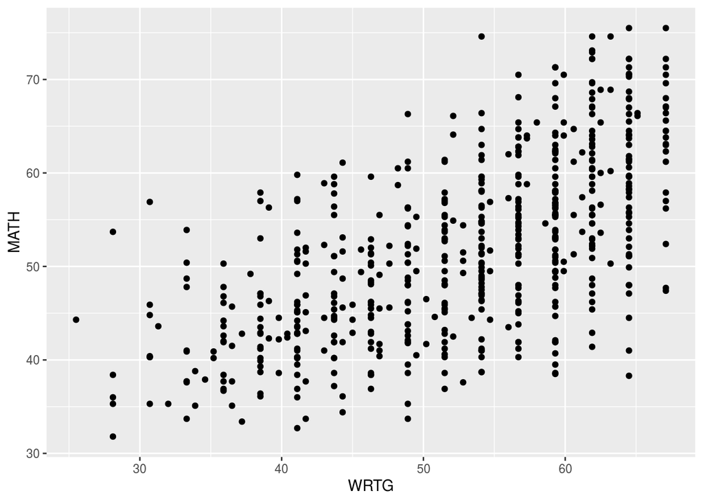

```r
library(ggplot2)

base=ggplot(data=hsb, aes(x=WRTG, y=MATH))
scatter = base + geom_point()
scatter
```

Vemos que hay una aparente relación. Calculemos los indices de correlación:

```r
f1=formula(~MATH + WRTG)

# camino parametrico
pearsonf1=cor.test(f1,data=hsb)[c('estimate','p.value')]

# camino no parametrico
spearmanf1=cor.test(f1,data=hsb,method='spearman')[c('estimate','p.value')]
```

Asumiendo un camino paramétrico, podemos pedir el coeficiente de *Pearson*, el cuál al ser calculado obtenemos 0.6326664 (con p-value= 0).

Si hubieramos seguido una ruta no paramétrica, informaríamos el coeficiente de *Spearman*:0.6415126 (con p-value= 0).

Ahora, consideremos que nos interesa saber *a la vez* la posible relación que pueda tener la variable que ha medido el desempeño en ciencias; así otra variable independiente sería la representada por la variable *SCI*. Como es otra variable *numérica* no podemos calcular la correlación de tres variables, pero podemos tratar de verlo visualmente:

- En tres dimensiones:

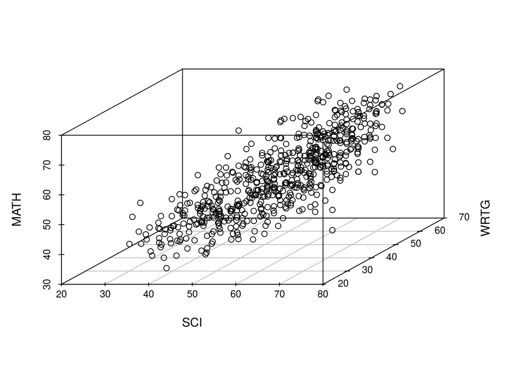

```r
library(scatterplot3d)
scatterplot3d(hsb[,c('SCI','WRTG','MATH')])
```

- En dos dimensiones:

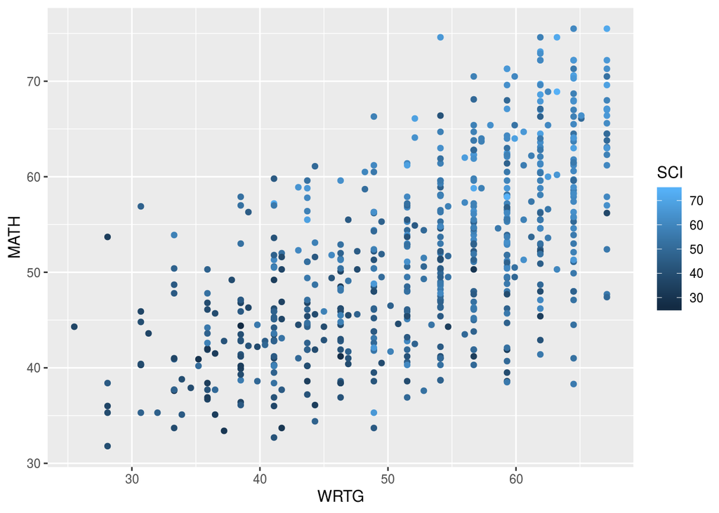

```r
base=ggplot(data=hsb, aes(x=WRTG, y=MATH))
base + geom_point(aes(color = SCI))
```

Calulemos las correlaciones:

```r
f2=formula(~MATH+SCI)

# camino parametrico
pearsonf2=cor.test(f2,data=hsb)[c('estimate','p.value')]

# camino no parametrico
spearmanf2=cor.test(f2,data=hsb, method='spearman')[c('estimate','p.value')]
```

Podríamos calcular la correlación de SCI con MATH, obteniendo el Pearson (0.6495261, p-value= 0) y el Spearman (0.6551515,p-value= 0).

Visualmente vemos relación, pero **no tenemos** un coeficiente para medir ello.

Finalmente, ¿si quisiéramos ver si el sexo tiene algun rol en todo esto? Como ésta es una variable *categórica* y *dicotómica*, lo primero que puede venir a la mente es esta gráfica:

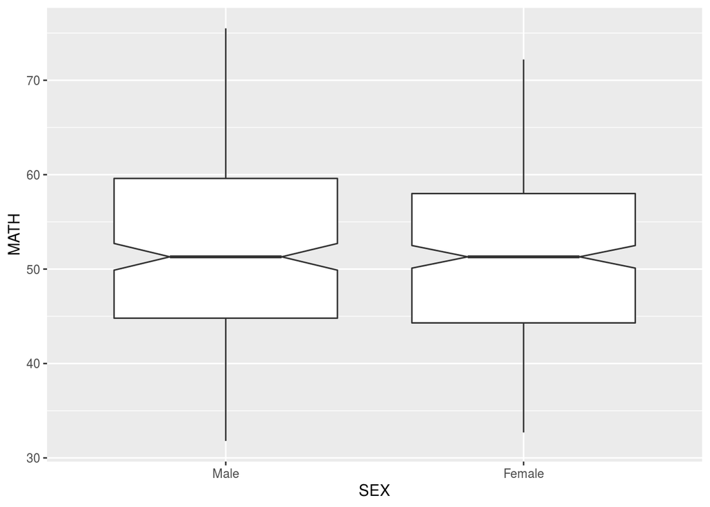

```r
base=ggplot(data=hsb, aes(x=SEX, y=MATH))
base + geom_boxplot(notch = T)
```

Los boxplots tienen un *notch* flanqueando a la *mediana*, para sugerir igualdad de medianas si éstos se intersectan; de ahi que parece no haber diferencia sustantiva entre hombres y mujeres en cuanto a su desempeño en MATH.

Una alternativa al boxplot seria las barras de error:

```r
library(ggpubr)
```

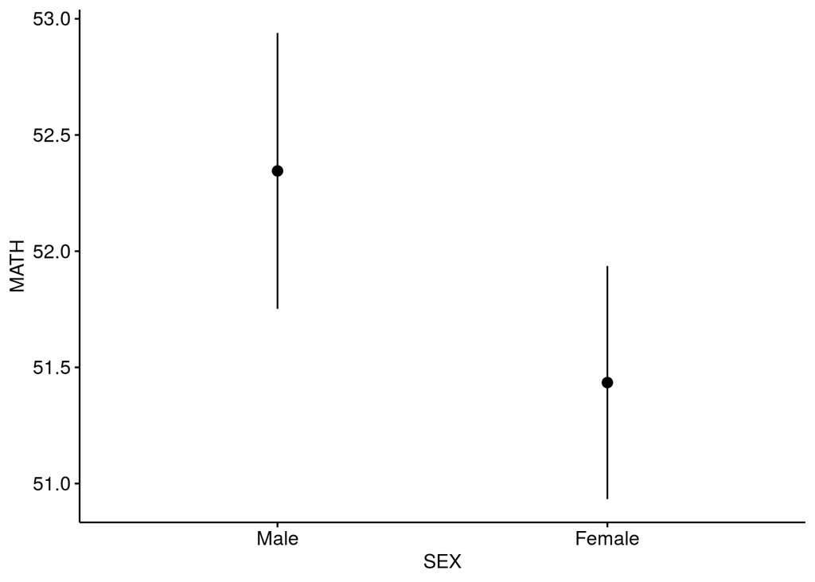

```r
ggerrorplot(data=hsb, x = "SEX", y = "MATH")
```

En este último caso, si las lineas (denotado por las barras de error de la media) se intersectan, sugeriria que los valores medios (en este caso la *media*) podrian ser iguales.

Verificar si hay o no igualdad entre distribuciones depende si las variables se distribuyen o no de manera normal:

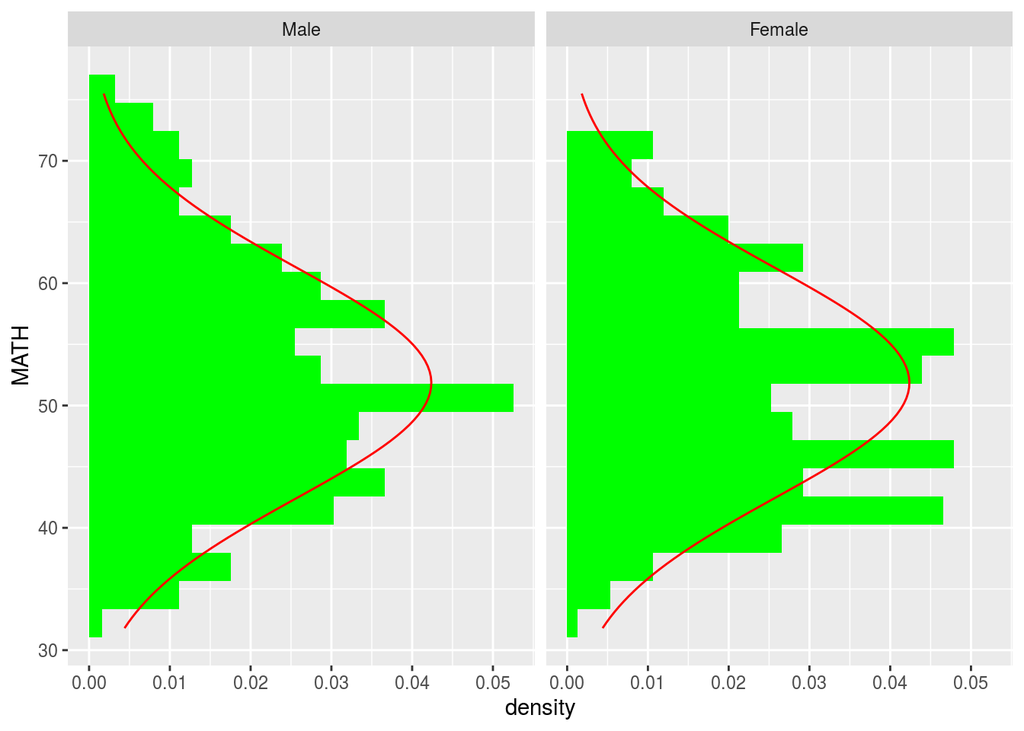

```r
library(ggplot2)
ggplot(hsb,aes(x=MATH)) +
  geom_histogram(aes(y = ..density..),bins = 20, fill='green') +
  stat_function(fun = dnorm, colour = "red",
                      args = list(mean = mean(hsb$MATH, na.rm = TRUE),
                                 sd = sd(hsb$MATH, na.rm = TRUE))) +
  facet_grid(~SEX) +
  coord_flip()
```

Nota que los histogramas de la data *real* tienen encima la curva *normal* que *idealmente* tendría esa data. La lejanía entre ellos, sugeriría no normalidad.

Se suele usar un qqplot para explorar la presencia/ausencia de normalidad:

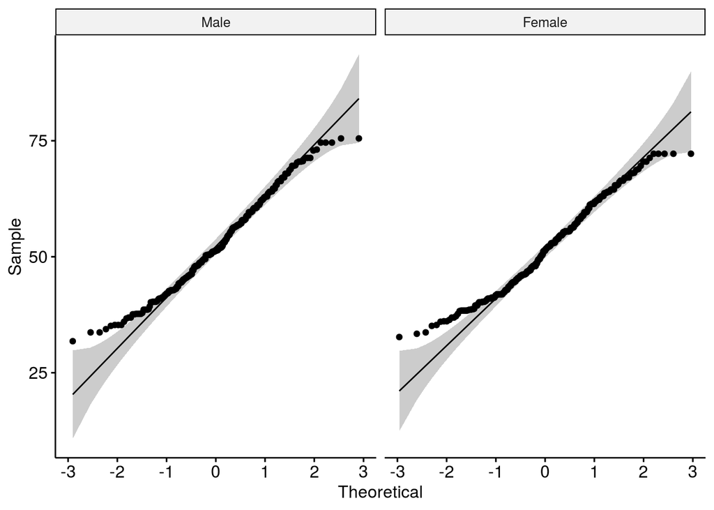

```r
# se sugiere normalidad si los puntos no se alejan de la diagonal.

library(ggpubr)
ggqqplot(data=hsb,x="MATH") + facet_grid(. ~ SEX)
```

Como ello no es fácil de discernir visualmente, tenemos por costumbre calcular algun coeficiente, como el *Shapiro-Wilk*:

```r
library(knitr)
library(magrittr)
library(kableExtra)
f4=formula(MATH~SEX)


tablag= aggregate(f4, hsb,
          FUN = function(x) {y <- shapiro.test(x); c(y$statistic, y$p.value)})

# para que se vea mejor:


shapiroTest=as.data.frame(tablag[,2])
names(shapiroTest)=c("W","Prob")


kable(cbind(tablag[1],shapiroTest))%>%
  kable_styling(bootstrap_options = c("striped", "hover"), full_width = F, position = "left")
```

| SEX | W | Prob |
| --- | --- | --- |
| Male | 0.9837903 | 0.0034565 |
| Female | 0.9790040 | 0.0001031 |

Esto nos sugiere un camino no paramétrico para ver la diferencia de valores medios, por lo que deberiamos usar la prueba de *Mann-Whitney* en vez de la *prueba t* para testaer la relación entre ambas.

```r
tf4=t.test(f4,data=hsb)[c('estimate','p.value')]
wilcoxf4=wilcox.test(f4,data=hsb)['p.value']
```

La prueba no paramétrica no rechazaría la igualdad de valores medios (Mann-Whitney con p valor = 0.3085543).

- Veamos como representar al sexo en nuestra gráfica entre WRTG y MATH:

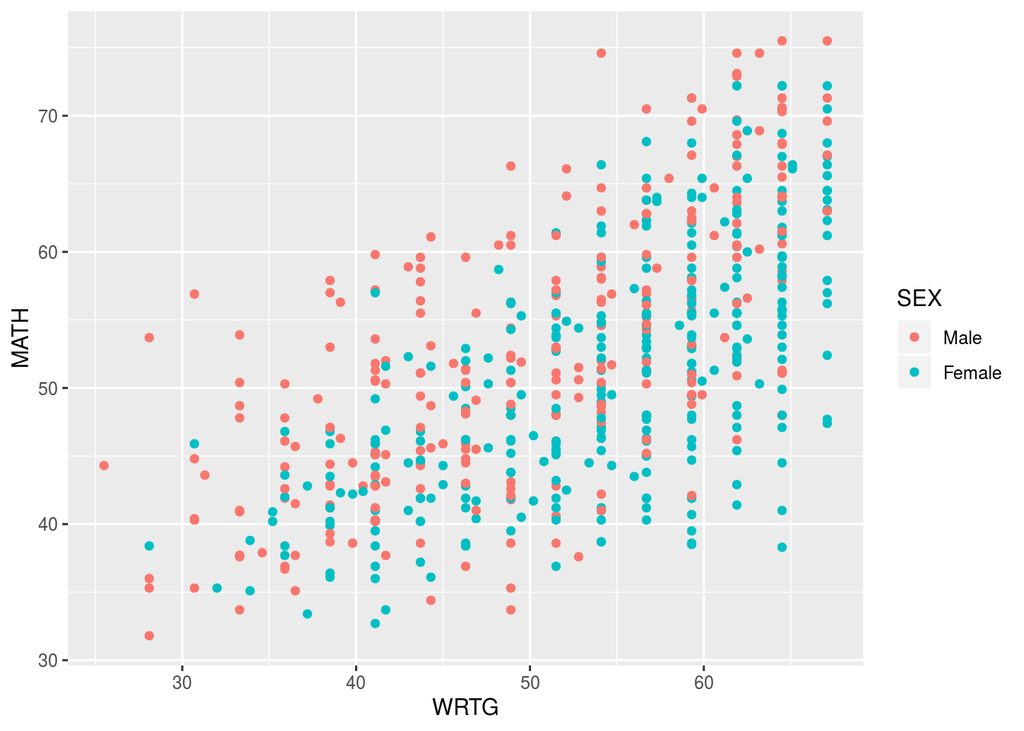

```r
base=ggplot(data=hsb, aes(x=WRTG, y=MATH))
base + geom_point(aes(color = SEX))
```

- Veamos como representar al sexo en nuestra gráfica entre WRTG, SCI y MATH:

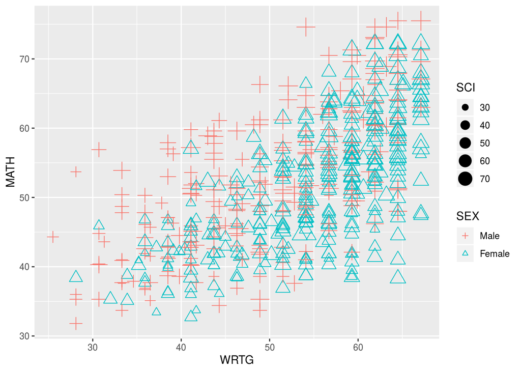

```r
base + geom_point(aes(size = SCI, color=SEX,shape=SEX)) + scale_shape_manual(values=c(3, 2))
```

Otra alternativa puede ser:

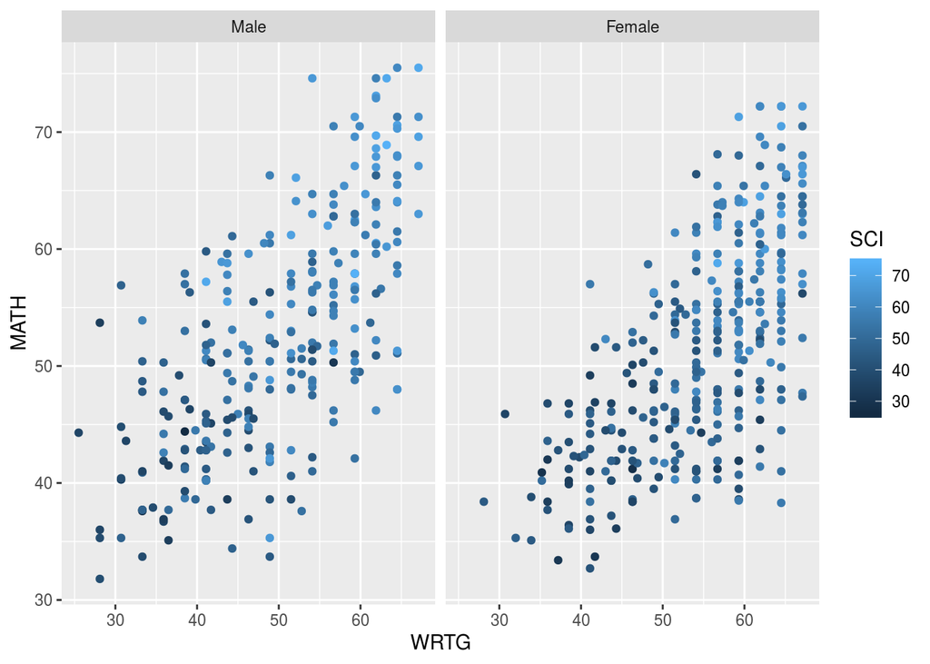

```r
base + geom_point(aes(color = SCI)) + facet_grid(~SEX)
```

Y claro:

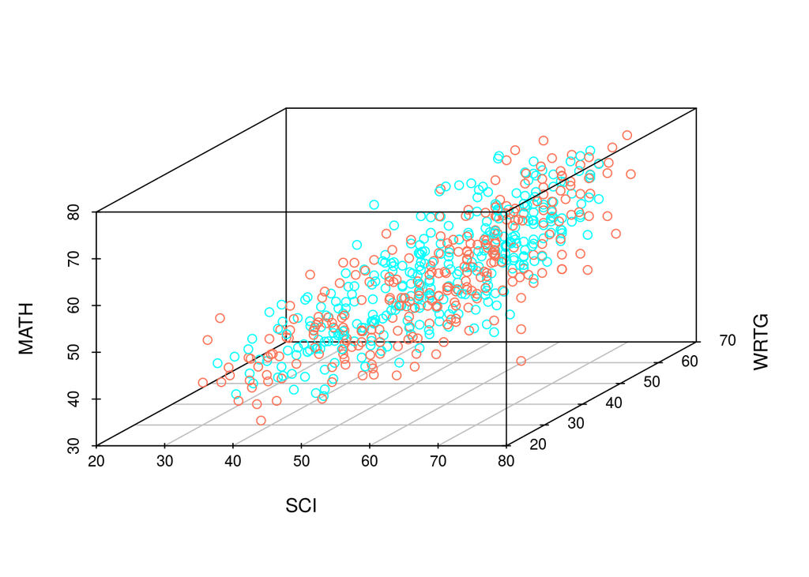

```r
paleta <- c("coral1","cyan" )
colors <- paleta[as.numeric(hsb$SEX)]
scatterplot3d(hsb[,c('SCI','WRTG','MATH')],color=colors)
```

En todos los gráficos vemos que los hombres y las mujeres están distribuidos por todo el gráfico, lo cual nos sugiere que no hay diferencias aun en dimensiones mayores a dos. Sin embargo, no tenemos una medida de cuanto cada uno afecta a nuestra dependiente.

De ahi que necesitamos la **regresión**.

## Regresión Lineal

La regresión es una técnica donde hay que definir una variable dependiente y una o más independientes. Las independientes pueden tener rol predictor, dependiendo del diseño de investigación, aunque por defecto tiene un rol explicativo.

La regresión sí quiere informar cuánto una variable (*independiente*) puede explicar la variación de otra (*dependiente*), de ahí que es una técnica para probar hipótesis direccionales o asimétricas (las correlaciones tiene hipótesis simétricas).

La regresión busca proponer un modelo, es decir una ecuación, que recoja como una variable explicaría a otra.Para nuestro caso la variable dependiente es MATH, y tendriamos hasta ahora tres modelos:

```r
modelo1=formula(MATH~WRTG)
modelo2=formula(MATH ~ WRTG + SCI)
modelo3= formula(MATH ~ WRTG + SCI + SEX)
```

Por ejemplo, para la hipótesis ‘*el nivel de desempeño en escritura afecta el desempeño en matemáticas*’, la regresión arrojaría este resultado:

```r
library(stargazer)
reg1=lm(modelo1,data=hsb)
stargazer(reg1,type = "html",intercept.bottom = FALSE)
```

|  | *Dependent variable:* |
| --- | --- |
|  | MATH |
| Constant | 19.769*** |
|  | (1.633) |
| WRTG | 0.612*** |
|  | (0.031) |
| Observations | 600 |
| R<sup>2</sup> | 0.400 |
| Adjusted R<sup>2</sup> | 0.399 |
| Residual Std. Error | 7.297 (df = 598) |
| F Statistic | 399.110*** (df = 1; 598) |
| *Note:* | p<0.1; p<0.05; p<0.01 |

Esto es información suficiente para representar esa relación con una ecuación. Como la ecuación sólo tiene una variable independiente podemos producir una recta sobre el gráfico de correlación:

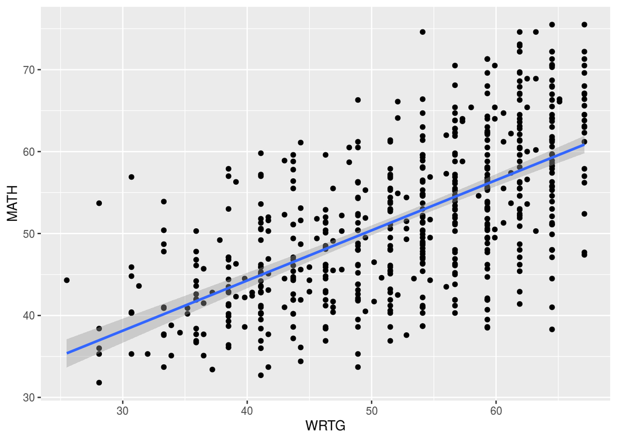

```r
ggplot(hsb, aes(x=WRTG, y=MATH)) +
  geom_point()+
  geom_smooth(method=lm)
```

Esa recta podemos representarla así:

$$MATH= 19.7690323 + 0.6123904 \cdot WRTG + \epsilon$$

Y sí queremos ver el efecto de SCI?

```r
reg2=lm(modelo2,data=hsb)
stargazer(reg2,type = "html",intercept.bottom = FALSE)
```

|  | *Dependent variable:* |
| --- | --- |
|  | MATH |
| Constant | 10.629*** |
|  | (1.630) |
| WRTG | 0.377*** |
|  | (0.033) |
| SCI | 0.415*** |
|  | (0.033) |
| Observations | 600 |
| R<sup>2</sup> | 0.524 |
| Adjusted R<sup>2</sup> | 0.523 |
| Residual Std. Error | 6.505 (df = 597) |
| F Statistic | 328.846*** (df = 2; 597) |
| *Note:* | p<0.1; p<0.05; p<0.01 |

En este caso, la regresión tendrá una formula con dos variables explicando la dependiente, así que en vez de producir una línea buscará producir un plano:

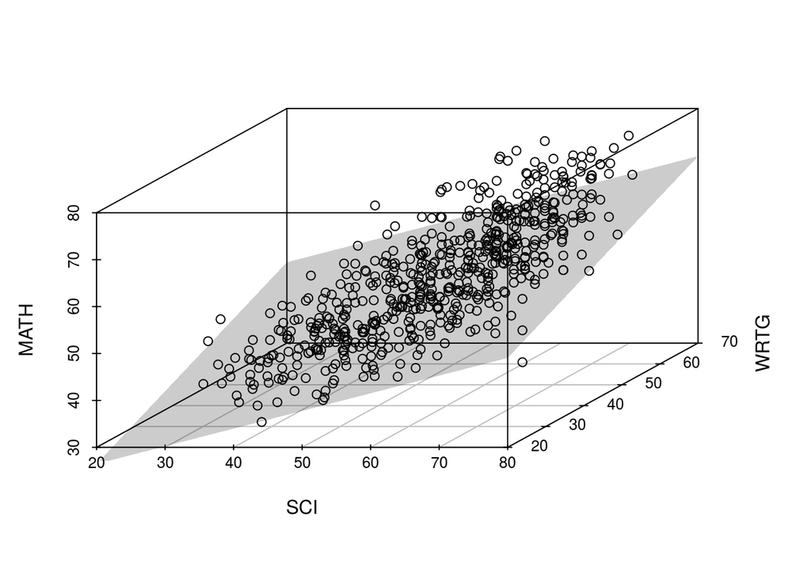

```r
library(scatterplot3d)
G  <- scatterplot3d(hsb[,c('SCI','WRTG','MATH')])
G$plane3d(reg2, draw_polygon = TRUE, draw_lines = FALSE)
```

Este plano podemos representarlo así:

$$MATH= 10.6285904 + 0.3765304 \cdot WRTG + 0.4152733 \cdot SCI + \epsilon$$

Es clave darse cuenta de otro detalle, que el coeficiente de WRTG ha variado en la fórmula ahora que está presente SCI ¿Por qué sucede esto? Veamoslo así: en el primer caso, WRTG y $\epsilon$ buscaban representar la variabilidad en MATH, y ahora, en el segundo caso, viene SCI para mejorar esa explicación; es así que el peso de la explicación ahora se recalcula y el coeficiente de WRTG deja de explicar lo que le corresponde a SCI, y $\epsilon$ también le entrega *algo* a SCI.

Como $\epsilon$ no tiene coeficiente, representamos su variación usando el error típico de los residuos o *residual standard error* (RSE). Nótese que éste ha variado de un modelo ha otro, ahora tenemos un RSE menor. Aquí vale la pena preguntarse si esta disminución del error es significativa, obteniendo:

```r
tanova=anova(reg1,reg2)
stargazer(tanova,type = 'html',summary = F,title = "Table de Análisis de Varianza")
```

**Table de Análisis de Varianza**

|  | Res.Df | RSS | Df | Sum of Sq | F | Pr(> F) |
| --- | --- | --- | --- | --- | --- | --- |
| 1 | 598 | 31,842.070 |  |  |  |  |
| 2 | 597 | 25,262.730 | 1 | 6,579.335 | 155.481 | 0 |

La comparación de modelos usando la tabla de análisis de varianza (anova) propone como hipótesis nula que los modelos no difieren (no se ha reducido el error al pasar de un modelo a otro). Como la comparación es *significativa* (vea el **P**), rechazamos igualdad de modelos: el modelo 2 sí reduce el error al incluir una variable más.

Finalmente, veamos el rol de sexo:

```r
reg3=lm(modelo3,data=hsb)
stargazer(reg3,type = "html",intercept.bottom = FALSE)
```

|  | *Dependent variable:* |
| --- | --- |
|  | MATH |
| Constant | 11.306*** |
|  | (1.630) |
| WRTG | 0.424*** |
|  | (0.036) |
| SCI | 0.375*** |
|  | (0.035) |
| SEXFemale | -1.922*** |
|  | (0.582) |
| Observations | 600 |
| R<sup>2</sup> | 0.533 |
| Adjusted R<sup>2</sup> | 0.530 |
| Residual Std. Error | 6.452 (df = 596) |
| F Statistic | 226.510*** (df = 3; 596) |
| *Note:* | p<0.1; p<0.05; p<0.01 |

Aunque no podemos graficar cuatro coordenadas, podemos usar elementos visuales:

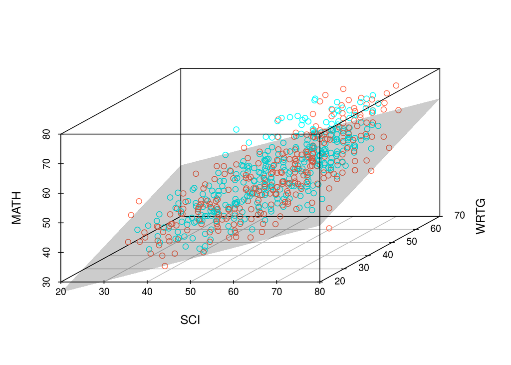

```r
library(scatterplot3d)
colors <- paleta[as.numeric(hsb$SEX)]
G  <- scatterplot3d(hsb[,c('SCI','WRTG','MATH')],color=colors)
G$plane3d(reg2, draw_polygon = TRUE, draw_lines = FALSE)
```

Nuestra nueva ecuación sería:

$$MATH= 11.306349 + 0.4235786 \cdot WRTG + 0.3748025 \cdot SCI + -1.9219692 \cdot SEX + \epsilon$$

Nuevamente podemos ver si añadir SEXO en este modelo representa una mejora al anterior:

```r
tanova=anova(reg1,reg2,reg3)
stargazer(tanova,type = 'html',summary = F,title = "Table de Análisis de Varianza")
```

**Table de Análisis de Varianza**

|  | Res.Df | RSS | Df | Sum of Sq | F | Pr(> F) |
| --- | --- | --- | --- | --- | --- | --- |
| 1 | 598 | 31,842.070 |  |  |  |  |
| 2 | 597 | 25,262.730 | 1 | 6,579.335 | 158.063 | 0 |
| 3 | 596 | 24,808.420 | 1 | 454.308 | 10.914 | 0.001 |

Finalmente, podemos resumir todo en esta tabla:

```r
library(stargazer)
stargazer(reg1,reg2,reg3, type = "html", title = "Modelos planteadas",digits = 2, single.row = F,no.space = F,intercept.bottom = FALSE,
          dep.var.caption="Variable dependiente:",
          dep.var.labels="Desempeño en Matemáticas",
          covariate.labels=c("Constante","Desempeño en Escritura","Desempeño en Ciencias","SEXO (mujer)"),
          keep.stat = c("n","adj.rsq","ser"),df = F,
          notes.label = "Notas:")
```

**Modelos planteadas**

|  | Variable dependiente: |  |  |
| --- | --- | --- | --- |
|  | Desempeño en Matemáticas |  |  |
|  | (1) | (2) | (3) |
| Constante | 19.77*** | 10.63*** | 11.31*** |
|  | (1.63) | (1.63) | (1.63) |
| Desempeño en Escritura | 0.61*** | 0.38*** | 0.42*** |
|  | (0.03) | (0.03) | (0.04) |
| Desempeño en Ciencias |  | 0.42*** | 0.37*** |
|  |  | (0.03) | (0.04) |
| SEXO (mujer) |  |  | -1.92*** |
|  |  |  | (0.58) |
| Observations | 600 | 600 | 600 |
| Adjusted R<sup>2</sup> | 0.40 | 0.52 | 0.53 |
| Residual Std. Error | 7.30 | 6.51 | 6.45 |
| Notas: | p<0.1; p<0.05; p<0.01 |  |  |

Graficamente:

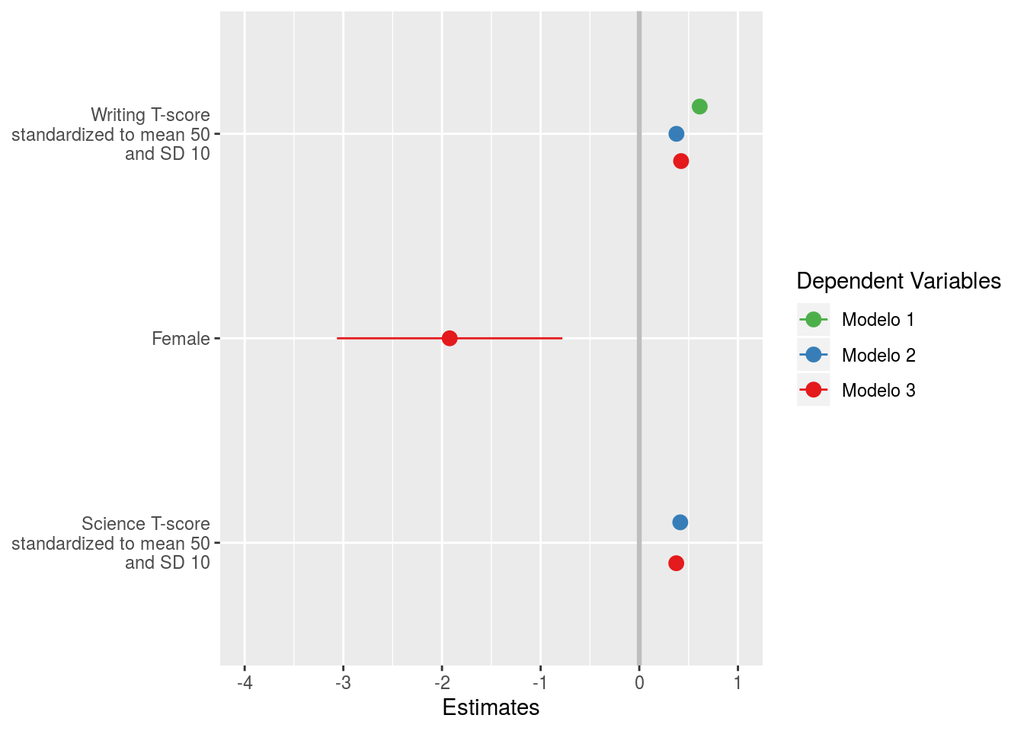

```r
library(ggplot2)
library(sjPlot)
plot_models(reg1,reg2,reg3,vline.color = "grey",m.labels=c("Modelo 1","Modelo 2","Modelo 3"))
```

## Diagnósticos de la Regresión

Para que se considere que el modelo de regresión elegido es el adecuado, debemos verificar algunos requisitos a posteriori:

**1. Linealidad**:

Se asume relación lineal entre Y y Xs:

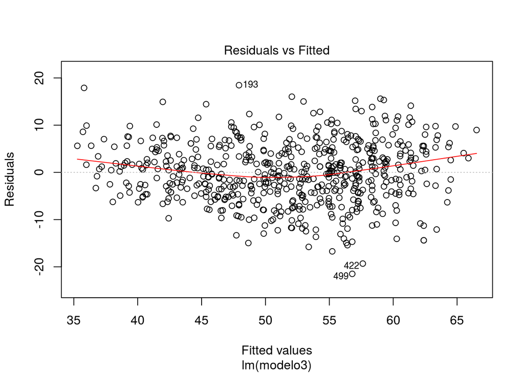

```r
# linea roja debe tender a horizontal
plot(reg3, 1)
```

**2. Homocedasticidad**

Se asume que el error del modelo de regresión no afecta la varianza o dispersión de la estimación ($\hat{MATH}$):

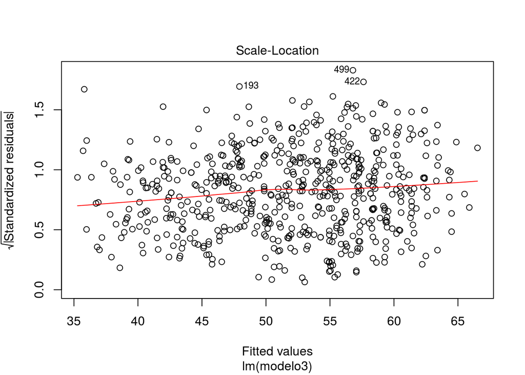

```r
# linea roja debe tender a horizontal
plot(reg3, 3)
```

También podemos utilizar el test de Breusch-Pagan:

```r
library(lmtest)
# null: modelo homocedastico
bptest(reg3)
```

```
##
##  studentized Breusch-Pagan test
##
## data:  reg3
## BP = 10.05, df = 3, p-value = 0.01815
```

La probabilidad de homocedasticidad es muy baja (p-value menor a 0.05), de ahi que se rechaza que el modelo muestre homocedasticidad.

**3. Normalidad de los residuos**

Los residuos, la diferencia entre MATH y $\hat{MATH}$, debe distribuirse de manera normal:

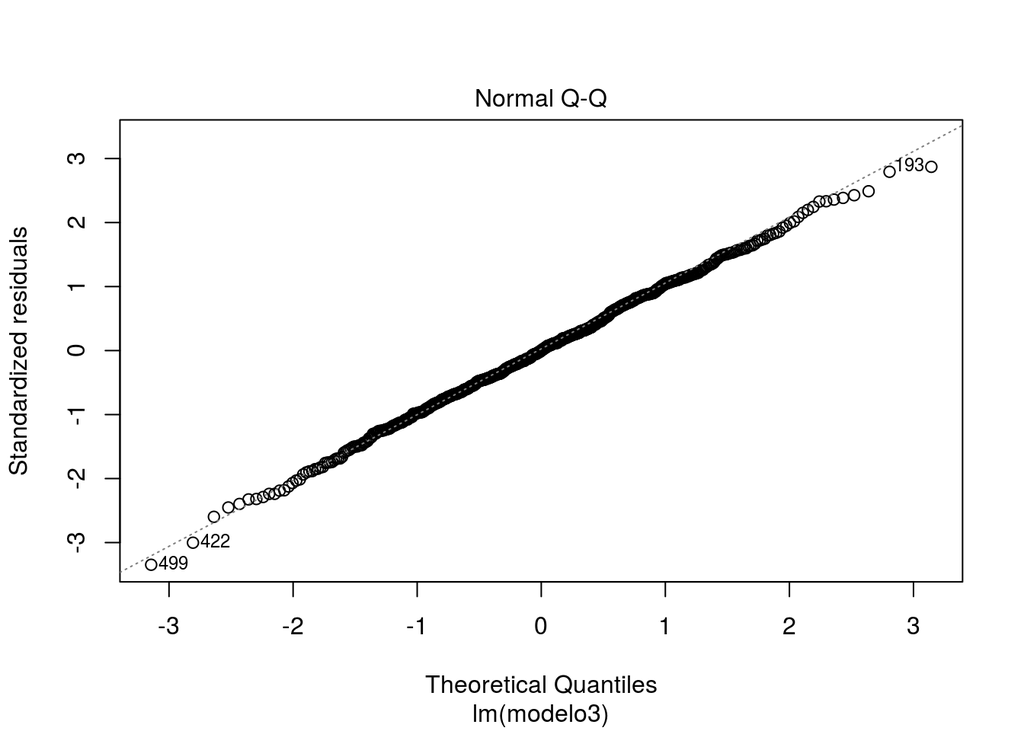

```r
# puntos cerca a la diagonal
plot(reg3, 2)
```

Podemos aplicar el test de Shapiro a los residuos:

```r
shapiro.test(reg3$residuals)
```

```
##
##  Shapiro-Wilk normality test
##
## data:  reg3$residuals
## W = 0.9989, p-value = 0.9776
```

**4. No multicolinelidad**

Si los predictores tienen una correlación muy alta entre sí, hay multicolinealidad, lo cual no es deseable:

```r
library(DescTools)
VIF(reg3) # > 5 es problematico
```

```
##     WRTG      SCI      SEX
## 1.755244 1.682589 1.209766
```

**5. Valores influyentes**:

Hay casos particulares, que tienen la capacidad de trastocar lo que casi todos puntos representan. A veces detectandolos y suprimiendolos, podemos ver un mejor modelo:

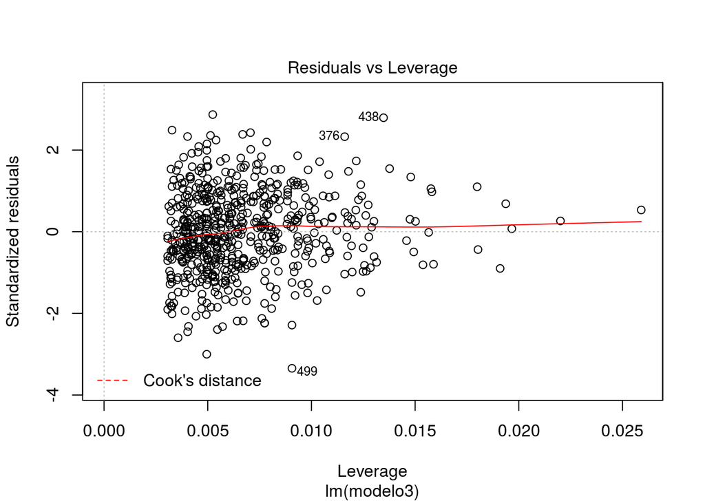

```r
plot(reg3, 5)
```

Asi podemos recuperar los casos influyentes:

```r
checkReg3=as.data.frame(influence.measures(reg3)$is.inf)
head(checkReg3)
```

```
##   dfb.1_ dfb.WRTG dfb.SCI dfb.SEXF dffit cov.r cook.d   hat
## 1  FALSE    FALSE   FALSE    FALSE FALSE FALSE  FALSE FALSE
## 2  FALSE    FALSE   FALSE    FALSE FALSE FALSE  FALSE FALSE
## 3  FALSE    FALSE   FALSE    FALSE FALSE FALSE  FALSE FALSE
## 4  FALSE    FALSE   FALSE    FALSE FALSE FALSE  FALSE FALSE
## 5  FALSE    FALSE   FALSE    FALSE FALSE FALSE  FALSE FALSE
## 6  FALSE    FALSE   FALSE    FALSE FALSE FALSE  FALSE FALSE
```

Normalmente le prestamos atencion al indice de Cook y a los valores predecidos (los *hat* values):

```r
checkReg3[checkReg3$cook.d | checkReg3$hat,]
```

```
##     dfb.1_ dfb.WRTG dfb.SCI dfb.SEXF dffit cov.r cook.d  hat
## 112  FALSE    FALSE   FALSE    FALSE FALSE  TRUE  FALSE TRUE
## 448  FALSE    FALSE   FALSE    FALSE FALSE  TRUE  FALSE TRUE
```

Tarea para la casa: * Vaya al http://ineidw.inei.gob.pe/ineidw/ y pruebe esta hipotesis:

La Tasa de Mortalidad Infantil a nivel provincial está influenciada por Tasa de Empleo Vulnerable, el Porcentaje de personas de 3 años a más cuya lengua materna es quechua, aymara, ashaninka u otra lengua nativa, por el Porcentaje de viviendas cuyo régimen de tenencia de vivienda es propia, y si la provincia aloja a la capital de la region.

Haga un reporte exhaustivo. _____

al INICIO

[VOLVER A CONTENIDOS](https://politicaygobiernopucp.github.io/estadistica_anapol2/)